# Module 7) DA - Analyzing Data with Python NUMPY

# Q.1 Convert a 1D array to a 2D array with 2 rows

```python
import numpy as np
original_array = np.arange(8)
```

```python
print("Original array: \n", original_array)
```

```
Original array:
 [0 1 2 3 4 5 6 7]
```

```python
resultant_array = original_array.reshape(2, 4)
```

```python
print("Converted array: \n", resultant_array)
```

```
Converted array:
 [[0 1 2 3]
 [4 5 6 7]]
```

# Q.2 Get the common items between a and b

# Input:

a = np.array([1,2,3,2,3,4,3,4,5,6]) b = np.array([7,2,10,2,7,4,9,4,9,8])

# Desired Output:

# array([2, 4])

```python
a = np.array([1,2,3,2,3,4,3,4,5,6])
b = np.array([7,2,10,2,7,4,9,4,9,8])
```

```python
print("Original arrays", a, ' ', b)
```

```
Original arrays [1 2 3 2 3 4 3 4 5 6]   [ 7  2 10  2  7  4  9  4  9  8]
```

```python
c = np.intersect1d(a, b)
```

```python
print("Common values", c)
```

```
Common values [2 4]
```

# Q.3 Get all items between 5 and 10 from a.

# Input:

a = np.array([2, 6, 1, 9, 10, 3, 27])

# Desired Output:

(array([6, 9, 10]),)

```python
A = np.array([2, 6, 1, 9, 10, 3, 27])
```

```python
print("Original array:")
print(A)
```

```
Original array:
[ 2  6  1  9 10  3 27]
```

```python
result = np.where(np.logical_and(A>=5, A<=10))
print("\nElements within range: index position")
print(result)
```

```
Elements within range: index position
(array([1, 3, 4], dtype=int64),)
```

# Q.4 Limit the number of items printed in python NumPy array a to a maximum of 6 elements.

# Input:

array([ 0, 1, 2, 3, 4, 5, 6, 7, 8, 9, 10, 11, 12, 13, 14])

# Desired Output:

array([ 0, 1, 2, ..., 12, 13, 14])

```python
np.array([ 0, 1, 2, 3, 4, 5, 6, 7, 8, 9, 10, 11, 12, 13, 14])
```

```
array([ 0,  1,  2,  3,  4,  5,  6,  7,  8,  9, 10, 11, 12, 13, 14])
```

```python
np.set_printoptions(threshold=6)
np.array([ 0, 1, 2, 3, 4, 5, 6, 7, 8, 9, 10, 11, 12, 13, 14])
```

```
array([ 0,  1,  2, ..., 12, 13, 14])
```

# 1. Compute the minimum, 25th percentile, median, 75th, and maximum of ser.

```python
import pandas as pd
```

```python
num_state = np.random.RandomState(100)
num_series = pd.Series(num_state.normal(10, 4, 20))
print("Original Series:")
print(num_series)
result = np.percentile(num_series, q=[0, 25, 50, 75, 100])
print("\nMinimum, 25th percentile, median, 75th, and maximum of a given series:")
print(result)
```

```
Original Series:
0      3.000938
1     11.370722
2     14.612143
3      8.990256
4     13.925283
5     12.056875
6     10.884719
7      5.719827
8      9.242017
9     11.020006
10     8.167892
11    11.740654
12     7.665620
13    13.267388
14    12.690883
15     9.582355
16     7.874878
17    14.118931
18     8.247458
19     5.526727
dtype: float64

Minimum, 25th percentile, median, 75th, and maximum of a given series:
[ 3.00093811  8.09463867 10.23353705 12.21537733 14.61214321]
```

# 2. Creating A Pandas Data Frame and Using Sample Data Sets

```python
dict = {'name':["aparna", "pankaj", "sudhir", "Geeku"],
        'degree': ["MBA", "BCA", "M.Tech", "MBA"],
        'score':[90, 40, 80, 98]}

df = pd.DataFrame(dict)

print(df)
```

```
     name  degree  score
0  aparna     MBA     90
1  pankaj     BCA     40
2  sudhir  M.Tech     80
3   Geeku     MBA     98
```

# 3. Using NumPy, create a Pandas Data Frame with five rows and three columns.

```python
import numpy as np
import pandas as pd

numpyArray = np.array([[15, 22, 43],
                       [33, 24, 56],
                      [12,85,65],
                      [54,98,65],
                      [5,4,6]])


panda_df = pd.DataFrame(data = numpyArray,
                        index = ["Row_1", "Row_2","Row_3","Row_4","Row_5"],
                        columns = ["Column_1",
                                   "Column_2", "Column_3"])

print(panda_df)
```

```
       Column_1  Column_2  Column_3
Row_1        15        22        43
Row_2        33        24        56
Row_3        12        85        65
Row_4        54        98        65
Row_5         5         4         6
```

# 4. For a Pandas Data Frame created from a NumPy array, what is the default behavior for the labels for the columns? For the rows?

# Ans --> When you create a Pandas DataFrame from a NumPy array, the default behavior for labels is as follows:

```
Columns Labels (Columns Index):
The default behavior for column labels in a Pandas DataFrame is to assign integer labels starting from 0 and increasing sequentially for each column in the DataFrame. These integer labels serve as the column index.

Row Labels (Row Index):
Similarly, the default behavior for row labels in a Pandas DataFrame is to assign integer labels starting from 0 and increasing sequentially for each row in the DataFrame. These integer labels serve as the row index.
```

```python
import pandas as pd
import numpy as np


data = np.array([[1, 2], [3, 4], [5, 6]])


df = pd.DataFrame(data)

print(df)
```

```
   0  1
0  1  2
1  3  4
2  5  6
```

# 5. take csv file contains at least 10,000 rows and 12 columns which numerical and text values according to that continue following steps.

```python
data = pd.read_csv('Downloads/Office City.csv')
```

```python
data
```

|  | City | Client ID | Client Name | Number of Records | Order ID | Zip Code | Goods Category | Goods Name | Profit | Row ID | Office City Sales | State |
| --- | --- | --- | --- | --- | --- | --- | --- | --- | --- | --- | --- | --- |
| 0 | Carbondale | 1069 | Pam Bennett | 1 | 87112 | 62901 | Office Furniture | Atlantic Metals Mobile 3-Shelf Bookcases, Cust... | 1152.4173 | 22164 | 1670.17 | Illinois |
| 1 | Crystal Lake | 3396 | Stuart Wiley | 1 | 87542 | 60014 | Office Furniture | Bush Heritage Pine Collection 5-Shelf Bookcase... | -140.7276 | 19370 | 2327.54 | Illinois |
| 2 | Granite City | 2860 | Joann Mullen | 1 | 88284 | 62040 | Office Furniture | Bush Mission Pointe Library | 199.3340 | 22651 | 5161.20 | Illinois |
| 3 | Romeoville | 1089 | Jon Padgett | 1 | 90131 | 60441 | Office Furniture | Bush Mission Pointe Library | -681.0948 | 21658 | 1249.31 | Illinois |
| 4 | Saint Charles | 1080 | Colleen Fletcher | 1 | 88465 | 60174 | Office Furniture | Bush Westfield Collection Bookcases, Dark Cher... | 67.6540 | 18965 | 435.53 | Illinois |
| ... | ... | ... | ... | ... | ... | ... | ... | ... | ... | ... | ... | ... |
| 9995 | Dubuque | 2151 | Melinda Rogers | 1 | 90404 | 52001 | Office Furniture | Hon Deluxe Fabric Upholstered Stacking Chairs,... | -162.8244 | 22555 | 248.84 | Iowa |
| 9996 | Muscatine | 1360 | Arlene Gibbons | 1 | 89598 | 52761 | Office Furniture | Novimex Swivel Fabric Task Chair | -270.0000 | 19083 | 724.61 | Iowa |
| 9997 | Muscatine | 1360 | Arlene Gibbons | 1 | 89597 | 52761 | Office Furniture | Office Star - Mid Back Dual function Ergonomic... | -150.2000 | 20005 | 326.72 | Iowa |
| 9998 | Marshalltown | 2794 | Connie Bunn | 1 | 87557 | 50158 | Office Furniture | Office Star - Task Chair with Contemporary Loo... | 205.8300 | 18333 | 1120.94 | Iowa |
| 9999 | West Chicago | 562 | Keith Fowler | 1 | 86352 | 60185 | Office Furniture | O'Sullivan 3-Shelf Heavy-Duty Bookcases | -592.9928 | 20071 | 410.69 | Illinois |

10000 rows × 12 columns

# 6. Write the code to show the number of rows and columns in data frame.

```python
df = pd.DataFrame(data)

num_rows, num_columns = df.shape

print("Number of rows:", num_rows)
print("Number of columns:", num_columns)
```

```
Number of rows: 10000
Number of columns: 12
```

# 7. How might you show the first few rows of data frame?

```python
df.head(10)
```

|  | City | Client ID | Client Name | Number of Records | Order ID | Zip Code | Goods Category | Goods Name | Profit | Row ID | Office City Sales | State |
| --- | --- | --- | --- | --- | --- | --- | --- | --- | --- | --- | --- | --- |
| 0 | Carbondale | 1069 | Pam Bennett | 1 | 87112 | 62901 | Office Furniture | Atlantic Metals Mobile 3-Shelf Bookcases, Cust... | 1152.4173 | 22164 | 1670.17 | Illinois |
| 1 | Crystal Lake | 3396 | Stuart Wiley | 1 | 87542 | 60014 | Office Furniture | Bush Heritage Pine Collection 5-Shelf Bookcase... | -140.7276 | 19370 | 2327.54 | Illinois |
| 2 | Granite City | 2860 | Joann Mullen | 1 | 88284 | 62040 | Office Furniture | Bush Mission Pointe Library | 199.3340 | 22651 | 5161.20 | Illinois |
| 3 | Romeoville | 1089 | Jon Padgett | 1 | 90131 | 60441 | Office Furniture | Bush Mission Pointe Library | -681.0948 | 21658 | 1249.31 | Illinois |
| 4 | Saint Charles | 1080 | Colleen Fletcher | 1 | 88465 | 60174 | Office Furniture | Bush Westfield Collection Bookcases, Dark Cher... | 67.6540 | 18965 | 435.53 | Illinois |
| 5 | Mount Prospect | 3131 | Jonathan Reilly | 1 | 86802 | 60056 | Office Furniture | Hon 4-Shelf Metal Bookcases | 440.7200 | 18175 | 1115.56 | Illinois |
| 6 | Northbrook | 3197 | Wallace Pugh | 1 | 90852 | 60062 | Office Furniture | O'Sullivan 2-Shelf Heavy-Duty Bookcases | -1414.4100 | 20206 | 510.40 | Illinois |
| 7 | Schaumburg | 1091 | Joshua Keller | 1 | 90140 | 60193 | Office Furniture | O'Sullivan 3-Shelf Heavy-Duty Bookcases | -213.3200 | 25530 | 311.86 | Illinois |
| 8 | West Chicago | 562 | Keith Fowler | 1 | 86352 | 60185 | Office Furniture | O'Sullivan 3-Shelf Heavy-Duty Bookcases | -592.9928 | 20071 | 410.69 | Illinois |
| 9 | Galesburg | 1793 | Derek Jernigan | 1 | 87853 | 61401 | Office Furniture | Riverside Palais Royal Lawyers Bookcase, Royal... | -13706.4640 | 21284 | 6968.90 | Illinois |

# 8. If you select a single column from the diamonds Data Frame, what will be the type of the return value?

```python
import seaborn as sns
```

```python
diamonds = sns.load_dataset("diamonds")
```

```python
diamonds
```

|  | carat | cut | color | clarity | depth | table | price | x | y | z |
| --- | --- | --- | --- | --- | --- | --- | --- | --- | --- | --- |
| 0 | 0.23 | Ideal | E | SI2 | 61.5 | 55.0 | 326 | 3.95 | 3.98 | 2.43 |
| 1 | 0.21 | Premium | E | SI1 | 59.8 | 61.0 | 326 | 3.89 | 3.84 | 2.31 |
| 2 | 0.23 | Good | E | VS1 | 56.9 | 65.0 | 327 | 4.05 | 4.07 | 2.31 |
| 3 | 0.29 | Premium | I | VS2 | 62.4 | 58.0 | 334 | 4.20 | 4.23 | 2.63 |
| 4 | 0.31 | Good | J | SI2 | 63.3 | 58.0 | 335 | 4.34 | 4.35 | 2.75 |
| ... | ... | ... | ... | ... | ... | ... | ... | ... | ... | ... |
| 53935 | 0.72 | Ideal | D | SI1 | 60.8 | 57.0 | 2757 | 5.75 | 5.76 | 3.50 |
| 53936 | 0.72 | Good | D | SI1 | 63.1 | 55.0 | 2757 | 5.69 | 5.75 | 3.61 |
| 53937 | 0.70 | Very Good | D | SI1 | 62.8 | 60.0 | 2757 | 5.66 | 5.68 | 3.56 |
| 53938 | 0.86 | Premium | H | SI2 | 61.0 | 58.0 | 2757 | 6.15 | 6.12 | 3.74 |
| 53939 | 0.75 | Ideal | D | SI2 | 62.2 | 55.0 | 2757 | 5.83 | 5.87 | 3.64 |

53940 rows × 10 columns

```python
carat_column = diamonds["carat"]
```

```python
carat_column
```

```
0        0.23
1        0.21
2        0.23
3        0.29
4        0.31
         ...
53935    0.72
53936    0.72
53937    0.70
53938    0.86
53939    0.75
Name: carat, Length: 53940, dtype: float64
```

```python
type(carat_column)
```

```
pandas.core.series.Series
```

# 9. Create a line plot using the x and y values provided below. Label the y-axis as “Y” and label the x-axis as “X”.

x = [3, 4, 5, 6] y = [1.5, 2, 2.5, 3]

```python
import matplotlib.pyplot as plt
```

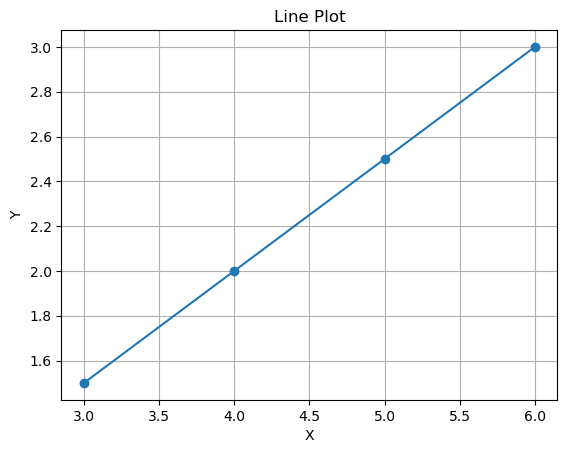

```python
x = [3, 4, 5, 6]
y = [1.5, 2, 2.5, 3]

plt.plot(x, y, marker='o')
plt.xlabel("X")
plt.ylabel("Y")
plt.title("Line Plot")
plt.grid(True)
plt.show()
```

# 10. Create an array of numbers between 0 and 6 with increments of 0.3 and name its “x”. Then on the same plot, plot x, x², x³, and x⁴. For consistency, use the following style lines respectively, “ro”, “bs”, “g”, and “:”. Lastly, make sure that the x-axis covers 0 to 6, while the y-axis spans from 0 to 125. Do not worry if you are not familiar with the style lines — you will recognize them as soon as you see the plot.

```python
x = np.arange(0, 6.3, 0.3)
```

```python
x
```

```
array([0. , 0.3, 0.6, ..., 5.4, 5.7, 6. ])
```

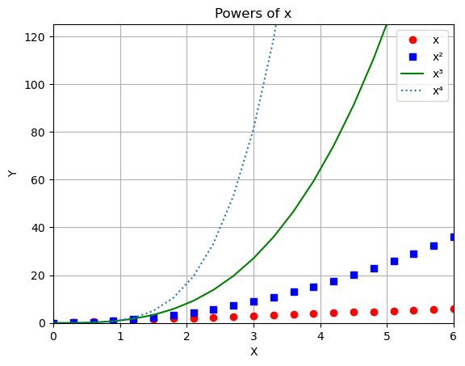

```python
x_square = x ** 2
x_cube = x ** 3
x_quad = x ** 4

plt.plot(x, x, 'ro', label='x')
plt.plot(x, x_square, 'bs', label='x²')
plt.plot(x, x_cube, 'g', label='x³')
plt.plot(x, x_quad, ':', label='x⁴')

plt.xlabel("X")
plt.ylabel("Y")
plt.title("Powers of x")
plt.xlim(0, 6)
plt.ylim(0, 125)
plt.legend()
plt.grid(True)
plt.show()
```

# 11. Heights and initials of a group of individuals are provided below. Create a bar plot titled

## “Height Comparison” to compare the heights among this group.

## height = [179, 155, 191, 152, 188, 177]

## names = ['QA', 'WB', 'EC', 'RD', 'TE', 'YF']

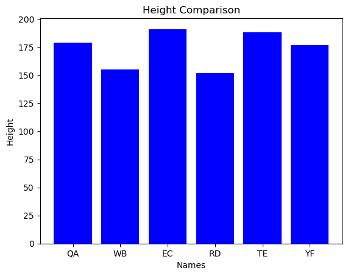

```python
height = [179, 155, 191, 152, 188, 177]
names = ['QA', 'WB', 'EC', 'RD', 'TE', 'YF']

plt.bar(names, height, color='blue')
plt.xlabel("Names")
plt.ylabel("Height")
plt.title("Height Comparison")
plt.show()
```

# 12. Plot a histogram of x, where x consists of 100,000 randomly-selected points with a normal distribution (hint: you can use numpy.random.randn() to generate the random points). The histogram should have 10 bins. Look at how the histogram changes when we try 20 and 50 bins.

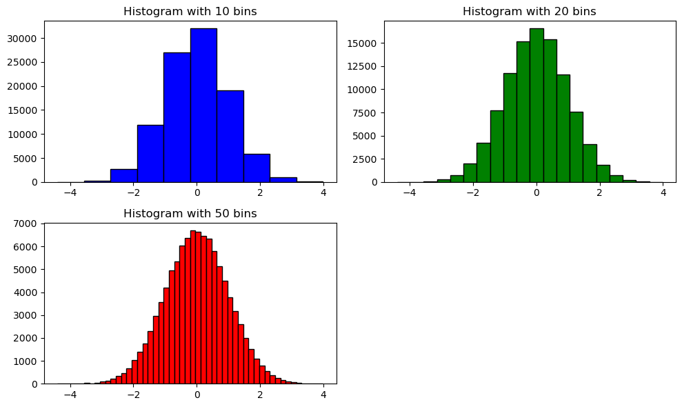

```python
x = np.random.randn(100000)


plt.figure(figsize=(10, 6))

plt.subplot(2, 2, 1)
plt.hist(x, bins=10, color='blue', edgecolor='black')
plt.title("Histogram with 10 bins")

plt.subplot(2, 2, 2)
plt.hist(x, bins=20, color='green', edgecolor='black')
plt.title("Histogram with 20 bins")

plt.subplot(2, 2, 3)
plt.hist(x, bins=50, color='red', edgecolor='black')
plt.title("Histogram with 50 bins")

plt.tight_layout()
plt.show()
```

# 13. What are the features of TensorFlow?

# TensorFlow is an open-source machine learning framework developed by the Google Brain team. It provides a flexible and efficient ecosystem for building and deploying various machine learning and deep learning models. Here are some of the key features of TensorFlow:

```
1) Symbolic Computation

2)Data Flow Graphs

3)Automatic Differentiation

4)Hardware and Platform Flexibility

5)High-Level APIs

6)Customizable

7)TensorBoard

8)Distributed Computing

9)Model Serving

10)Community and Ecosystem
```

## Overall, TensorFlow's powerful features make it a popular choice for researchers, engineers, and developers working on a wide range of machine learning and deep learning projects.

# 14. List a few limitations of TensorFlow.

# Steep Learning Curve: TensorFlow's low-level nature and complex computational graph abstraction can make it challenging for beginners to grasp. While high-level APIs like Keras have improved this, working with advanced features still requires a deep understanding.

# Verbosity: Writing TensorFlow code, especially for complex models, can be verbose due to the need to define the entire computational graph. This can lead to longer and less intuitive code compared to some other frameworks.

# Dynamic Graphs: While TensorFlow 2.0 and later versions introduced eager execution and more dynamic graph capabilities, it was historically criticized for having a static graph approach that hindered interactive development and debugging.

# Limited Mobile and Embedded Support: While TensorFlow has support for mobile and embedded platforms, integrating TensorFlow models into mobile apps can sometimes be challenging due to issues like model size and compatibility.

# Debugging and Error Messages: Debugging TensorFlow code can be complex, and error messages might not always provide clear insights into the root cause of issues, especially when dealing with graph construction and optimization errors.

# Performance Tuning: While TensorFlow offers hardware acceleration options like GPUs and TPUs, optimizing performance for specific hardware configurations can be challenging and might require specialized knowledge.

# Memory Management: TensorFlow's memory management can be intricate, and improper memory usage can lead to memory leaks or inefficient resource utilization, especially when dealing with large datasets.

# Complexity for Simple Tasks: While TensorFlow is highly capable of handling complex tasks, it can sometimes feel like overkill for simple machine learning tasks that could be accomplished with simpler libraries.

# Development and API Changes: TensorFlow has gone through several major revisions, leading to changes in APIs and best practices. This can make it difficult to keep up with the latest developments and migrate projects between versions.

# Competition from Other Frameworks: While TensorFlow was one of the pioneers in the deep learning framework space, it faces competition from other popular frameworks like PyTorch, which might offer more intuitive APIs and development experiences for certain use cases.

It's important to note that many of these limitations have been addressed in newer versions of TensorFlow (2.x and later) with the introduction of features like eager execution and improved APIs. Developers should carefully consider their specific requirements and project goals when choosing a machine learning framework.

# 15. What do you know about supervised and unsupervised machine learning?

# Supervised and unsupervised machine learning are two main categories of machine learning techniques, each serving distinct purposes in data analysis and pattern recognition.

# Supervised Machine Learning:

## Supervised learning is a type of machine learning where the model is trained on labeled data, meaning that the input data is paired with corresponding target or output labels. The goal of supervised learning is to learn a mapping from input features to the correct output labels, so the model can make accurate predictions on new, unseen data.

# There are two main types of supervised learning tasks:

## Classification: In classification, the goal is to predict a categorical label or class. The model is trained to assign input data points to one of several predefined classes. Examples include email spam detection, image classification, and sentiment analysis.

## Regression: In regression, the goal is to predict a continuous numeric value. The model learns a relationship between input features and a numeric target. Examples include predicting house prices, stock prices, and temperature forecasts.

### Common algorithms used in supervised learning include linear regression, decision trees, support vector machines (SVMs), and neural networks. Supervised learning requires a labeled dataset for both training and evaluation.

# Unsupervised Machine Learning:

## Unsupervised learning involves working with unlabeled data, where the goal is to discover inherent patterns, structures, or relationships within the data. Unlike supervised learning, there are no predefined output labels to guide the learning process.

# There are two main types of unsupervised learning tasks:

## Clustering: Clustering involves grouping similar data points into clusters or groups based on some similarity measure. It helps identify natural groupings within the data. Examples include customer segmentation and document clustering.

## Dimensionality Reduction: Dimensionality reduction techniques aim to reduce the number of input features while retaining meaningful information. This can help in visualizing high-dimensional data or reducing the computational complexity of models. Principal Component Analysis (PCA) is a common technique used for dimensionality reduction.

### Common algorithms used in unsupervised learning include k-means clustering, hierarchical clustering, and autoencoders.

# Semi-Supervised Learning and Self-Supervised Learning:

## There are also intermediate forms of learning between supervised and unsupervised learning:

## Semi-Supervised Learning: This approach uses a combination of labeled and unlabeled data. It's useful when labeling data is expensive or time-consuming. The model leverages the limited labeled data along with the structure of the unlabeled data.

## Self-Supervised Learning: Self-supervised learning is a recent approach that uses the data itself to generate labels for training. It involves designing tasks where the model predicts missing or transformed parts of the data. This approach can be useful when labeled data is scarce.

### Both supervised and unsupervised learning play crucial roles in various machine learning applications, and the choice between them depends on the nature of the data and the problem you're trying to solve.